# Walking through the peer connectedness meta-analysis

Veronica Cole

The biggest portion of this code corresponds to the regression analyses reported in Tables 1-4. This is written out in *regressions.R*.

The first thing we’ll do is basic data management steps which are the same across all imputations. We’ll create separate fields for each type of effect size, log-transform any odds ratios that are exponentiated, and reverse-code all the reverse-coded indicators. Note that “REV1” is the reverse code indicator for peer connectedness, and “REV2” is the reverse code indicator for substance use. We’re going to have to un-reverse them later when we generate plots, which is messy but the only way to go about it.

```r
rm(list=ls())

set.seed(58)

library(dplyr)
library(metafor)
library(mice)
library(knitr)
library(here)
library(ggplot2)
library(raster)
library(RColorBrewer)


test <- readRDS(here("data/effectsheet.rds"))

#Generate a count for which effect is which
names(test)[1] <- "Study"
test <- test %>% group_by(Study) %>% mutate(Effect = row_number(Study))


test$logodds <- NA
test$r <- NA
test$d <- NA
test$b <- NA
test$other <- NA
test$logodds.se <- NA
test$r.se <- NA
test$d.se <- NA
test$b.se <- NA
test$other.se <- NA
test$original.type <- test$Type

#pubyear = year since 1996
test$pubyear <- test$pubyear - 1996


#need to get these effects log-transformed before doing anything.
for (o in 1:nrow(test)) {
  if (test$Type[o] == "OR" | test$Type[o] == "aOR") {
    test$Type[o] <- "logodds"
    test$Value[o] <- log(test$Value[o])
  }
}


#Now reverse everything that needs to be reverse-coded
test$Value <- test$Value * (1 - 2*test$REV1) * (1 - 2*test$REV2)


#Now we will put every effect size and SE in its own field
log.list <- c("logodds")
original.log.list <- c("log-odds ratio (logistic regression coefficient)", "logistic regression B",
                       "logistic regression coefficient", "logistic regression", "logistic regression coefficient (PH model)")
r.list <- c("r", "latent variable correlations", "partial correlation", "z")
d.list <- c("d", "Cohens d**")
b.list <- c("beta", "b", "standardized regression coefficient", "standardized beta")


for (e in 1:nrow(test)) {
  if ((test$Type[e] %in% c(log.list, original.log.list)) == TRUE) {
    test$logodds[e] <- test$Value[e]
    test$logodds.se[e] <- test$SE[e]
  } else if ((test$Type[e] %in% r.list) == TRUE) {
    test$r[e] <- test$Value[e]
    test$r.se[e] <- test$SE[e]
  } else if ((test$Type[e] %in% d.list) == TRUE) {
    test$d[e] <- test$Value[e]
    test$d.se[e] <- test$SE[e]
  } else if ((test$Type[e] %in% b.list) == TRUE) {
    test$b[e] <- test$Value[e]
    test$b.se[e] <- test$SE[e]
  } else {
    test$other[e] <- test$Value[e]
    test$other.se[e] <- test$SE[e]
  }
}
```

This is the function we’re going to use to impute standard errors in cases where we don’t have an exact p. value. What we actually impute is the p. value, and we calculate the standard error based on that.

```r
#imputation function
impute.p <- function(old.p) {
  new.p <- old.p
  if (is.na(old.p) == FALSE) {
    if (old.p == "ns" | old.p == "p >.05" | old.p == "p > .05") {
      new.p <- runif(1, .05, 1)
    }
    if (old.p == "p < .05" | old.p == ".05" | old.p == "0.05") {
      new.p <- runif(1, .01, .05)
    }
    if (old.p == "p < .01" | old.p == ".01" | old.p == "0.01") {
      new.p <- runif(1, .001, .01)
    }
    if (old.p == "p < .001" | old.p == ".001" | old.p == "0.001" | old.p == "0.0" | old.p == "0") {
      new.p <- runif(1, .0001, .001)
    }
  }
  as.numeric(new.p)
}
```

Now we will calculate all the standard errors for effects for which we have enough information to do so. This consists of (1) log-odds ratios which have confidence intervals attached to them, and (2) correlation coefficients.

```r
#Now let's get the SE's for odds ratios which entails either:
#1. transforming the delta-method SE given by the authors, typically calculated as OR*se(logodds)
#(so to get se(logodds) we do se(OR)/OR)
#2. or, more commonly, using the CI to calculate the SE
for (r in 1:nrow(test)) {
  if (((test$Type[r] %in% log.list) == TRUE) & (is.na(test$SE[r]) == FALSE)) {
    test$SE[r]  <- test$SE[r]/test$original.value[r]
  }
  if (((test$Type[r] %in% log.list) == TRUE) & (is.na(test$SE[r]) == TRUE)) {
    test$SE[r]  <- (log(as.numeric(test$CI_upper[r])) - log(as.numeric(test$CI_lower[r])))/ (2*1.96)
  }
}


#Finally, we will get the SE's for the correlations
for (p in 1:nrow(test)) {
  if((test$Type[p] %in% r.list) == TRUE) {
    test$r.se[p] <- sqrt((1-test$r[p]^2)/(test$N[p] - 2))
  }
}

test$r.v <- test$r.se^2
```

Now let’s create the codes for each level of peer connectedness and substance use variables.

```r
test$PCMeasure <- NA
test$PCMeasure[test$SP == 1] <- "Sociometric Popularity"
test$PCMeasure[test$SL == 1] <- "Sociometric Likeability"
test$PCMeasure[test$SM == 1 & test$FR == 1 & test$ISO != 1] <- "aaSociometric Friendship"
test$PCMeasure[test$ISO == 1] <- "Sociometric Isolation"
test$PCMeasure[test$SM == 0 & test$FR == 1 & test$ISO != 1] <- "aSelf-Reported Number of Friends"
test$PCMeasure[test$LON == 1] <- "Loneliness"
test$PCMeasure[test$TIME == 1] <- "Time Spent with Friends"
test$PCMeasure[test$SUP == 1] <- "Support from Friends"
test$PCMeasure[test$GENSUP == 1] <- "Support from All Peers"
test$PCMeasure[test$SRP == 1] <- "Self-Rated Popularity"
test$PCMeasure[test$COM == 1] <- "Social Competency"


test$Substance <- NA
test$SUMeasure <- NA
test$Timeframe <- NA
test$Substance[test$ALC == 1] <- "Alcohol Use"
test$Substance[test$BINGE == 1] <- "Binge Drinking or Drunkenness"
test$Substance[test$MJ == 1] <- "Marijuana Use"
test$Substance[test$TOB == 1] <- "Nicotine Use"
test$Substance[test$OD == 1] <- "Other Drug Use"
test$Substance[test$COMP == 1] <- "Compound Measure of Drug Use"
test$SUMeasure[test$Q == 1] <- "Quantity of Use"
test$SUMeasure[test$F == 1] <- "Frequency of Use"
test$SUMeasure[test$ANY == 1] <- "Any Use"
test$SUMeasure[test$PROB == 1] <- "Problem"
test$SUMeasure[test$Q == 0 & test$F == 0 & test$ANY == 0 & test$PROB == 0] <- "aaNo Measure Specified"
test$Timeframe[test$REC == 1] <- "Recent Use"
test$Timeframe[test$LT == 1] <- "Lifetime Use"
test$Timeframe[test$LT == 0 & test$REC == 0] <- "aNo Frequency Specified"
```

### Meta-regression models

We will generate 5 imputations, mostly to impute data for standard errors and ages. The rationale for this is described in the Supplemental Materials. But the first thing we’ll do is just generate the 5 datasets.

```r
dat.list <- vector(mode = "list", length = 5)

for (rep1 in 1:5) {

  dat.list[[rep1]] <- test

  #Now we will impute SE's on the basis of imputed p. values
  #Note that we are doing this for all values, including log-odds as well as r and d
  #but we had to log-transform OR's first because the SE's only make sense for the log-odds
  dat.list[[rep1]]$sig.impute <- NA
  for (s in 1:nrow(dat.list[[rep1]])) {
    if(nchar(dat.list[[rep1]]$Sig.[s]) > 0) {
      dat.list[[rep1]]$sig.impute[s] <- impute.p(dat.list[[rep1]]$Sig.[s])
      dat.list[[rep1]]$SE[s] <- abs(dat.list[[rep1]]$Value[s])/qnorm(1 - dat.list[[rep1]]$sig.impute[s]/2)
    }
  }

  #Note that we have some SE's that come in as 0
  #We will fix them to some arbitrarily small value instead
  for (v in 1:nrow(dat.list[[rep1]])) {
    if (is.na(dat.list[[rep1]]$SE[v]) == FALSE) {
      if (dat.list[[rep1]]$SE[v] == 0) {
        dat.list[[rep1]]$SE[v] <- .00001
      }
      if (dat.list[[rep1]]$SE[v] > abs(dat.list[[rep1]]$Value[v]*10)) {
        dat.list[[rep1]]$SE[v] <- abs(dat.list[[rep1]]$Value[v]*10)
      }
    }
  }



  #Now impute age
  for (a in 1:nrow(dat.list[[rep1]])) {
    if (is.na(dat.list[[rep1]]$Age[a]) == TRUE) {
      if(is.na(dat.list[[rep1]]$Age_lower[a]) == FALSE) {
        dat.list[[rep1]]$Age[a] <- runif(1,dat.list[[rep1]]$Age_lower[a],dat.list[[rep1]]$Age_upper[a])
      } else {
        dat.list[[rep1]]$Age[a] <- runif(1, 10, 19)
      }
    }
  }


  #Now repeat the step that puts every different type of effect in its own column
  for (e in 1:nrow(dat.list[[rep1]])) {
    if ((dat.list[[rep1]]$Type[e] %in% c(log.list, original.log.list)) == TRUE) {
      dat.list[[rep1]]$logodds[e] <- dat.list[[rep1]]$Value[e]
      dat.list[[rep1]]$logodds.se[e] <- dat.list[[rep1]]$SE[e]
    } else if ((dat.list[[rep1]]$Type[e] %in% r.list) == TRUE) {
      dat.list[[rep1]]$r[e] <- dat.list[[rep1]]$Value[e]
      dat.list[[rep1]]$r.se[e] <- dat.list[[rep1]]$SE[e]
    } else if ((dat.list[[rep1]]$Type[e] %in% d.list) == TRUE) {
      dat.list[[rep1]]$d[e] <- dat.list[[rep1]]$Value[e]
      dat.list[[rep1]]$d.se[e] <- dat.list[[rep1]]$SE[e]
    } else if ((dat.list[[rep1]]$Type[e] %in% b.list) == TRUE) {
      dat.list[[rep1]]$b[e] <- dat.list[[rep1]]$Value[e]
      dat.list[[rep1]]$b.se[e] <- dat.list[[rep1]]$SE[e]
    } else {
      dat.list[[rep1]]$other[e] <- dat.list[[rep1]]$Value[e]
      dat.list[[rep1]]$other.se[e] <- dat.list[[rep1]]$SE[e]
    }
  }
  dat.list[[rep1]]$logodds.v <- dat.list[[rep1]]$logodds.se^2

}
```

Now it’s time to actually run the models! These are the models for zero-order effects, the ones shown in Table 1 (with all zero-order effects) and Table 2 (with just correlation coefficients). Note that this involves converting among all the different types of zero-order effects. This entails an ugly run of code where we first convert Cohen’s $d$ to correlation coefficient $r$. We then convert the log-odds, which we got from contingency tables, to $d$ and then to $r$.

```r
#Make the objects which will hold all the imputed datasets
zero.order <- vector(mode = "list", length = 5)
just.r <- vector(mode = "list", length = 5)

#Make the objects which will hold all the model results
zo.model <- vector(mode = "list", length = 5)
r.model <- vector(mode = "list", length = 5)

for (rep2 in 1:5) {

  zero.order[[rep2]] <- subset(dat.list[[rep2]], dat.list[[rep2]]$Number == 0)

  #A bit hackish, but we're going to give converted values of r and d the "converted" label to distinguish them from things that were in that scale originally
  #So we will initialize values of "r.converted" etc. to the original value of r (or r.v, or d, or d.v) if it already existed; this will be blank for cases in which it didn't exist

  zero.order[[rep2]]$r.converted <- zero.order[[rep2]]$r
  zero.order[[rep2]]$r.converted.v <- zero.order[[rep2]]$r.v
  zero.order[[rep2]]$d.converted <- zero.order[[rep2]]$d
  zero.order[[rep2]]$d.converted.v <- zero.order[[rep2]]$d.se^2


  for (z in 1:nrow(zero.order[[rep2]])) {
    #convert d to r
    if (zero.order[[rep2]]$Type[z] == "d" | zero.order[[rep2]]$Type[z] == "Cohens d**") {
      zero.order[[rep2]]$r.converted[z] <- zero.order[[rep2]]$d.converted[z]/sqrt(4 + zero.order[[rep2]]$d.converted[z]^2)
      zero.order[[rep2]]$r.converted.v[z] <- (16*zero.order[[rep2]]$d.converted.v[z])/((4 + zero.order[[rep2]]$d.converted[z]^2)^3)
    }
    #convert logodds to d in cases in which there are no covariates (i.e., zero-order = true)
    #then convert those d's to r's
    #note that the last 2 lines of this for loop replicate what we did above; just want to make sure it gets converted for everyone
    if (zero.order[[rep2]]$Type[z] == "logodds" | zero.order[[rep2]]$Type[z] == "logistic regression coefficient") {
      zero.order[[rep2]]$d.converted[z] <- (sqrt(3)/pi)*zero.order[[rep2]]$Value[z]
      zero.order[[rep2]]$d.converted.v[z] <- (zero.order[[rep2]]$SE[z]^2)*(3/(pi^2))
      zero.order[[rep2]]$r.converted[z] <- zero.order[[rep2]]$d.converted[z]/sqrt(4 + zero.order[[rep2]]$d.converted[z]^2)
      zero.order[[rep2]]$r.converted.v[z] <- (16*zero.order[[rep2]]$d.converted.v[z])/((4 + zero.order[[rep2]]$d.converted[z]^2)^3)
    }
  }

  zero.order[[rep2]] <-  escalc(measure = "ZCOR", ri = r.converted, ni = N, data = zero.order[[rep2]])


  #There weren't enough cases with "Support from All Peers" in any of the zero-order measures to allow the model to be estimated
  #Then, within the ones that were in correlation metric originally,
  zero.order[[rep2]] <- zero.order[[rep2]][which(zero.order[[rep2]]$PCMeasure != "Support from All Peers"),]
  #and there weren't enough cases with "Sociometric Isolation" when you consider only the effect sizes that were in correlation metric originally
  just.r[[rep2]] <- zero.order[[rep2]][which(zero.order[[rep2]]$Type == "r"),]
  just.r[[rep2]] <- just.r[[rep2]][which(just.r[[rep2]]$PCMeasure != "Sociometric Isolation"),]


  ## MODEL ESTIMATION SECTION ##

  #Model 1: All zero-order effects, even those which were converted, included
  zo.model[[rep2]] <- rma.mv(yi,
                      vi,
                      random = ~ 1 | Study/Effect,
                      data = zero.order[[rep2]],
                      mods = ~ PCMeasure +
                        Substance + Timeframe + SUMeasure +
                        Age + Gender + Europe + AAO + AfricaME + LatinAmerica + Longitudinal + PC_outcome +
                        pubyear + AddHealth)


  r.model[[rep2]] <- rma.mv(yi,
                         vi,
                         random = ~ 1 | Study/Effect,
                         data = just.r[[rep2]],
                         mods = ~ PCMeasure +
                           Substance + Timeframe + SUMeasure +
                           Age + Gender + Europe + AAO + AfricaME + LatinAmerica + Longitudinal + PC_outcome +
                           pubyear + AddHealth)


  }
```

We now run the models for partial effects. This includes the models in Table 3 (for logistic regression) and Table 4 (for linear regression). Two things merit attention here, from the perspective of recreating our decision-making. First, note that for both logistic regression and linear regression, we eliminate certain categories. This is because there were few enough effects that we couldn’t actually run the models (e.g., only one or two papers report logistic regression with certain measures of peer connectedness). Second, note that for log-odds we only used effects with variances greater than .0001 or less than 10. Third, as noted in the paper, the Cochran test of moderators in the aggregate (i.e., $Q_M$) is not significant for the model for linear regressions, even though the specific effect of sociometric popularity is. (This will become clear in the next chunk of code.) Thus, we ran a pared-down model which did not include any of the control variables, as none of these were significant. As will be shown in the next chunk, the test for moderators is highly significant when the pared-down model is run.

```r
#Make the objects that will hold all the imputed datasets
partial <- vector(mode = "list", length = 5)
logreg.partial <- vector(mode = "list", length = 5)
linreg.partial <- vector(mode = "list", length = 5)
linreg.subset <- vector(mode = "list", length = 5)

#Make the objects that will hold all the model results
linreg.model <- vector(mode = "list", length = 5)
logreg.model <- vector(mode = "list", length = 5)
linreg.pared.down <- vector(mode = "list", length = 5)

for (rep3 in 1:5){
    partial[[rep3]] <- subset(dat.list[[rep3]], dat.list[[rep3]]$Number > 0)


    #Further split the partial dataset into one for logistic regression and one for linear regression
    logreg.partial[[rep3]] <- subset(partial[[rep3]], partial[[rep3]]$Type %in% c(original.log.list, log.list))
    linreg.partial[[rep3]] <- subset(partial[[rep3]], partial[[rep3]]$Type == "b" | partial[[rep3]]$Type == "beta" | partial[[rep3]]$Type == "standardized beta" | partial[[rep3]]$Type ==
                               "standardized regression coefficient")
    linreg.partial[[rep3]]$t.reg <- linreg.partial[[rep3]]$Value/linreg.partial[[rep3]]$SE


    linreg.partial[[rep3]] <- escalc(measure = "ZPCOR", ti = t.reg, ni = N, mi = Number, data = linreg.partial[[rep3]])
    linreg.partial[[rep3]] <- linreg.partial[[rep3]][which(abs(linreg.partial[[rep3]]$t.reg) < 10) , ]


    ##Linear regression model
    which.linreg <- which(linreg.partial[[rep3]]$PCMeasure %in%
                            c("aaSociometric Friendship", "Sociometric Likeability",
                              "Sociometric Popularity", "Support from Friends", "Time Spent with Friends", "aSelf-Reported Number of Friends", "Self-Reported Number of Friends"))
    linreg.subset[[rep3]] <- linreg.partial[[rep3]][which.linreg,]

    linreg.model[[rep3]] <- rma.mv(yi,
                         vi,
                         random = ~ 1 | Study/Effect,
                         data = linreg.subset[[rep3]],
                         mods = ~ PCMeasure +
                           Substance + Timeframe + SUMeasure +
                           Age + Gender + Europe + AAO + AfricaME + LatinAmerica + Longitudinal + pubyear + AddHealth +
                           Number + PC_outcome + Including_peer_use + Including_other_peer_connectedness)

    linreg.pared.down[[rep3]] <- rma.mv(yi,
                         vi,
                         random = ~ 1 | Study/Effect,
                         data = linreg.subset[[rep3]],
                         mods = ~ PCMeasure +
                           Substance + Timeframe + SUMeasure + Including_peer_use)


    ##Logistic regression model
    for (q in 1:nrow(logreg.partial[[rep3]])) {
      if (is.na(logreg.partial[[rep3]]$logodds.v[q]) == FALSE) {
        if(logreg.partial[[rep3]]$logodds.v[q] < .0001 |
           logreg.partial[[rep3]]$logodds.v[q] > 10)
          {logreg.partial[[rep3]]$logodds.v[q] <- NA}
      }
    }

    #Logistic regression model
    logreg.model[[rep3]] <- rma.mv(logodds,
                           logodds.v,
                           random = ~ 1 | Study/Effect,
                           data = logreg.partial[[rep3]],
                           mods = ~ PCMeasure +
                             Substance + Timeframe + SUMeasure +
                             Age + Gender + Europe + AAO + AfricaME + LatinAmerica + Longitudinal + pubyear + AddHealth +
                             Number + PC_outcome + Including_peer_use + Including_other_peer_connectedness)




}
```

This will just write out each imputed dataset to a different *.csv file.

```r
for (rep4 in 1:5) {
  #### Now write out each imputed dataset
  zero.order.out <- zero.order[[rep4]][,c("Study", "Effect", "r.converted", "r.converted.v", "PCMeasure", "Substance", "Timeframe", "SUMeasure", "Age", "Gender", "Europe", "AAO", "AfricaME", "LatinAmerica", "Longitudinal", "pubyear", "Number", "PC_outcome", "Including_peer_use", "Including_other_peer_connectedness", "AddHealth")]
  names(zero.order.out)[c(3,4)] <- c("yi", "vi")
  write.table(zero.order.out, here(paste0("data/zeroorder_table_imp",rep4,".csv")), sep = ",", row.names = FALSE, col.names = TRUE)

  just.r.out <- just.r[[rep4]][,c("Study", "Effect", "r.converted", "r.converted.v", "PCMeasure", "Substance", "Timeframe", "SUMeasure", "Age", "Gender", "Europe", "AAO", "AfricaME", "LatinAmerica", "Longitudinal", "pubyear", "Number", "PC_outcome", "Including_peer_use", "Including_other_peer_connectedness", "AddHealth")]
  names(just.r.out)[c(3,4)] <- c("yi", "vi")
  write.table(just.r.out, here(paste0("data/justr_table_imp",rep4,".csv")), sep = ",", row.names = FALSE, col.names = TRUE)

  linreg.subset.out <- linreg.subset[[rep4]][,c("Study", "Effect", "yi", "vi", "PCMeasure", "Substance", "Timeframe", "SUMeasure", "Age", "Gender", "Europe", "AAO", "AfricaME", "LatinAmerica", "Longitudinal", "pubyear", "Number", "PC_outcome", "Including_peer_use", "Including_other_peer_connectedness", "AddHealth")]
  write.table(linreg.subset.out, here(paste0("data/linreg_table_imp",rep4,".csv")), sep = ",", row.names = FALSE, col.names = TRUE)


  logreg.subset.out <- logreg.partial[[rep4]][,c("Study", "Effect", "logodds", "logodds.v", "PCMeasure", "Substance", "Timeframe", "SUMeasure", "Age", "Gender", "Europe", "AAO", "AfricaME", "LatinAmerica", "Longitudinal", "pubyear", "Number", "PC_outcome", "Including_peer_use", "Including_other_peer_connectedness", "AddHealth")]
  names(logreg.subset.out)[c(3,4)] <- c("yi", "vi")
  write.table(logreg.subset.out, here(paste0("data/logreg_table_imp",rep4,".csv")), sep = ",", row.names = FALSE, col.names = TRUE)
}
```

We’ll pool all the models together using multiple imputation, but first let’s get some of the information that the multiple imputation routine won’t give us. This includes the number of studies, the number of effects, and the number of levels of each of the focal variables (i.e., the number of studies reporting the effects of each type of peer connectedness variable and substance use variable). Note that in some cases the number of effects changes across imputations, because different effects are dropped due to having excessively high or low variances. In this case we choose the number from the first imputation.

```r
#Get the number of studies and effects in each model
zo.model[[1]]
```

```
##
## Multivariate Meta-Analysis Model (k = 564; method: REML)
##
## Variance Components:
##
##             estim    sqrt  nlvls  fixed        factor
## sigma^2.1  0.0072  0.0851     60     no         Study
## sigma^2.2  0.0164  0.1280    564     no  Study/Effect
##
## Test for Residual Heterogeneity:
## QE(df = 534) = 6182.3793, p-val < .0001
##
## Test of Moderators (coefficients 2:30):
## QM(df = 29) = 70.2412, p-val < .0001
##
## Model Results:
##
##                                            estimate      se     zval    pval
## intrcpt                                      0.0366  0.1258   0.2911  0.7710
## PCMeasureaSelf-Reported Number of Friends    0.0183  0.0868   0.2109  0.8329
## PCMeasureLoneliness                          0.0451  0.0611   0.7382  0.4604
## PCMeasureSelf-Rated Popularity               0.0152  0.0352   0.4306  0.6667
## PCMeasureSocial Competency                   0.0495  0.0405   1.2211  0.2221
## PCMeasureSociometric Isolation               0.0921  0.0503   1.8324  0.0669
## PCMeasureSociometric Likeability             0.0386  0.0349   1.1084  0.2677
## PCMeasureSociometric Popularity              0.2017  0.0356   5.6608  <.0001
## PCMeasureSupport from Friends                0.0452  0.0326   1.3869  0.1655
## PCMeasureTime Spent with Friends             0.0758  0.0254   2.9894  0.0028
## SubstanceBinge Drinking or Drunkenness       0.0162  0.0330   0.4888  0.6250
## SubstanceCompound Measure of Drug Use       -0.0131  0.0380  -0.3459  0.7294
## SubstanceMarijuana Use                      -0.0240  0.0253  -0.9481  0.3431
## SubstanceNicotine Use                       -0.0260  0.0210  -1.2377  0.2158
## SubstanceOther Drug Use                     -0.0161  0.0306  -0.5272  0.5981
## TimeframeLifetime Use                       -0.0300  0.0508  -0.5913  0.5543
## TimeframeRecent Use                         -0.0179  0.0419  -0.4288  0.6681
## SUMeasureAny Use                             0.0613  0.0848   0.7234  0.4694
## SUMeasureFrequency of Use                    0.0474  0.0725   0.6531  0.5137
## SUMeasureProblem                             0.0022  0.0814   0.0267  0.9787
## SUMeasureQuantity of Use                     0.0097  0.0883   0.1093  0.9129
## Age                                         -0.0061  0.0066  -0.9353  0.3497
```

[output cut: 27 more lines]

```
## SUMeasureFrequency of Use                  -0.0948  0.1895
## SUMeasureProblem                           -0.1574  0.1617
## SUMeasureQuantity of Use                   -0.1635  0.1828
## Age                                        -0.0190  0.0067
## Gender                                     -0.0006  0.0005
## Europe                                     -0.0492  0.1059
## AAO                                        -0.1636  0.0613
## AfricaME                                   -0.2319  0.0557
## Longitudinal1                              -0.0304  0.0419
## PC_outcome                                 -0.0550  0.0284
## pubyear                                    -0.0029  0.0087
## AddHealth                                  -0.0958  0.1109
##
## ---
## Signif. codes:  0 '***' 0.001 '**' 0.01 '*' 0.05 '.' 0.1 ' ' 1
```

```r
linreg.model[[1]]
```

```
##
## Multivariate Meta-Analysis Model (k = 82; method: REML)
##
## Variance Components:
##
##             estim    sqrt  nlvls  fixed        factor
## sigma^2.1  0.0015  0.0384     27     no         Study
## sigma^2.2  0.0008  0.0280     82     no  Study/Effect
##
## Test for Residual Heterogeneity:
## QE(df = 55) = 168.3726, p-val < .0001
##
## Test of Moderators (coefficients 2:27):
## QM(df = 26) = 28.8187, p-val = 0.3194
##
## Model Results:
##
##                                            estimate      se     zval    pval
## intrcpt                                      0.0935  0.1210   0.7731  0.4395
## PCMeasureaSelf-Reported Number of Friends    0.0512  0.0598   0.8551  0.3925
## PCMeasureSociometric Likeability             0.0084  0.0490   0.1709  0.8643
## PCMeasureSociometric Popularity              0.0953  0.0462   2.0646  0.0390
## PCMeasureSupport from Friends                0.0485  0.0471   1.0299  0.3031
## PCMeasureTime Spent with Friends             0.0590  0.0387   1.5233  0.1277
## SubstanceBinge Drinking or Drunkenness      -0.0014  0.0197  -0.0691  0.9449
## SubstanceCompound Measure of Drug Use        0.0461  0.0267   1.7292  0.0838
## SubstanceMarijuana Use                      -0.0060  0.0255  -0.2366  0.8130
## SubstanceNicotine Use                        0.0025  0.0171   0.1462  0.8837
## TimeframeLifetime Use                        0.0010  0.0524   0.0199  0.9841
## TimeframeRecent Use                          0.0066  0.0418   0.1587  0.8739
## SUMeasureAny Use                            -0.0815  0.0724  -1.1263  0.2600
## SUMeasureFrequency of Use                   -0.0702  0.0768  -0.9141  0.3606
## SUMeasureProblem                            -0.1273  0.0847  -1.5021  0.1331
## SUMeasureQuantity of Use                    -0.0033  0.0919  -0.0360  0.9713
## Age                                         -0.0011  0.0062  -0.1758  0.8605
## Gender                                      -0.0002  0.0002  -0.6819  0.4953
## Europe                                      -0.0597  0.0635  -0.9408  0.3468
## AAO                                         -0.0588  0.1060  -0.5547  0.5791
## Longitudinal1                               -0.0322  0.0310  -1.0402  0.2982
## pubyear                                      0.0026  0.0033   0.7763  0.4376
```

[output cut: 21 more lines]

```
## SUMeasureQuantity of Use                   -0.1835  0.1768
## Age                                        -0.0133  0.0111
## Gender                                     -0.0006  0.0003
## Europe                                     -0.1841  0.0647
## AAO                                        -0.2666  0.1490
## Longitudinal1                              -0.0929  0.0285
## pubyear                                    -0.0039  0.0091
## AddHealth                                  -0.0830  0.1511
## Number                                     -0.0075  0.0056
## PC_outcome                                 -0.0852  0.0498
## Including_peer_useyes                      -0.0774  0.0745
## Including_other_peer_connectednessyes      -0.0992  0.0592
##
## ---
## Signif. codes:  0 '***' 0.001 '**' 0.01 '*' 0.05 '.' 0.1 ' ' 1
```

```r
logreg.model[[1]]
```

```
##
## Multivariate Meta-Analysis Model (k = 352; method: REML)
##
## Variance Components:
##
##             estim    sqrt  nlvls  fixed        factor
## sigma^2.1  0.1840  0.4289     49     no         Study
## sigma^2.2  0.0218  0.1478    352     no  Study/Effect
##
## Test for Residual Heterogeneity:
## QE(df = 319) = 2154.8449, p-val < .0001
##
## Test of Moderators (coefficients 2:33):
## QM(df = 32) = 86.7339, p-val < .0001
##
## Model Results:
##
##                                            estimate      se     zval    pval
## intrcpt                                     -0.0955  0.5952  -0.1604  0.8725
## PCMeasureaSelf-Reported Number of Friends    0.0540  0.1218   0.4438  0.6572
## PCMeasureLoneliness                          0.0385  0.0954   0.4038  0.6863
## PCMeasureSelf-Rated Popularity               0.2990  0.1010   2.9615  0.0031
## PCMeasureSociometric Isolation              -0.1565  0.0451  -3.4667  0.0005
## PCMeasureSociometric Likeability            -0.2884  0.2494  -1.1561  0.2476
## PCMeasureSociometric Popularity             -0.0060  0.1079  -0.0561  0.9553
## PCMeasureSupport from All Peers              0.3234  0.0934   3.4611  0.0005
## PCMeasureSupport from Friends               -0.0231  0.0650  -0.3556  0.7222
## PCMeasureTime Spent with Friends             0.0919  0.0770   1.1937  0.2326
## SubstanceBinge Drinking or Drunkenness       0.0222  0.0520   0.4261  0.6700
## SubstanceCompound Measure of Drug Use       -0.1310  0.1716  -0.7633  0.4453
## SubstanceMarijuana Use                      -0.0207  0.0366  -0.5653  0.5719
## SubstanceNicotine Use                       -0.0933  0.0375  -2.4851  0.0130
## SubstanceOther Drug Use                     -0.0560  0.0783  -0.7147  0.4748
## TimeframeLifetime Use                        0.4192  0.4989   0.8403  0.4007
## TimeframeRecent Use                          0.4491  0.4974   0.9030  0.3665
## SUMeasureFrequency of Use                   -0.0438  0.0712  -0.6143  0.5390
## SUMeasureProblem                             0.1621  0.1597   1.0154  0.3099
## SUMeasureQuantity of Use                    -0.0137  0.1030  -0.1332  0.8940
## Age                                          0.0231  0.0136   1.6926  0.0905
## Gender                                       0.0005  0.0007   0.7380  0.4605
```

[output cut: 33 more lines]

```
## Gender                                     -0.0008   0.0018
## Europe                                     -0.6810   0.1098
## AAO                                         0.0518   0.5383    *
## AfricaME                                   -0.3204   0.6531
## LatinAmerica                               -0.0499   1.0602    .
## Longitudinal1                              -0.1746   0.0633
## pubyear                                    -0.0765  -0.0167   **
## AddHealth                                  -0.4121   0.3749
## Number                                     -0.0187   0.0242
## PC_outcome                                 -1.2416   0.5707
## Including_peer_useyes                      -0.0009   0.6028    .
## Including_other_peer_connectednessyes      -0.2440   0.2723
##
## ---
## Signif. codes:  0 '***' 0.001 '**' 0.01 '*' 0.05 '.' 0.1 ' ' 1
```

```r
#Get the number of studies reporting each of the following types of effects (i.e., k in Tables 1-4)

table(zero.order[[1]]$PCMeasure)
```

```
##
##         aaSociometric Friendship aSelf-Reported Number of Friends
##                               86                                4
##                       Loneliness            Self-Rated Popularity
##                               12                               29
##                Social Competency            Sociometric Isolation
##                               25                               33
##          Sociometric Likeability           Sociometric Popularity
##                              121                               86
##             Support from Friends          Time Spent with Friends
##                               90                               89
```

```r
table(zero.order[[1]]$Substance)
```

```
##
##                   Alcohol Use Binge Drinking or Drunkenness
##                           199                            49
##  Compound Measure of Drug Use                 Marijuana Use
##                            83                            53
##                  Nicotine Use                Other Drug Use
##                           158                            33
```

```r
table(zero.order[[1]]$SUMeasure)
```

```
##
## aaNo Measure Specified                Any Use       Frequency of Use
##                     18                    191                    304
##                Problem        Quantity of Use
##                     48                     14
```

```r
table(zero.order[[1]]$Timeframe)
```

```
##
## aNo Frequency Specified            Lifetime Use              Recent Use
##                      63                      78                     434
```

```r
table(just.r[[1]]$PCMeasure)
```

```
##
## aaSociometric Friendship               Loneliness    Self-Rated Popularity
##                       63                        5                       28
##        Social Competency  Sociometric Likeability   Sociometric Popularity
##                       13                      121                       86
##     Support from Friends  Time Spent with Friends
##                       83                       36
```

```r
table(just.r[[1]]$Substance)
```

```
##
##                   Alcohol Use Binge Drinking or Drunkenness
##                           170                            43
##  Compound Measure of Drug Use                 Marijuana Use
##                            81                            34
##                  Nicotine Use                Other Drug Use
##                            79                            28
```

```r
table(just.r[[1]]$SUMeasure)
```

```
##
## aaNo Measure Specified                Any Use       Frequency of Use
##                     18                    149                    222
##                Problem        Quantity of Use
##                     36                     10
```

```r
table(just.r[[1]]$Timeframe)
```

```
##
## aNo Frequency Specified            Lifetime Use              Recent Use
##                      39                      47                     349
```

```r
table(linreg.subset[[1]]$PCMeasure)
```

```
##
##         aaSociometric Friendship aSelf-Reported Number of Friends
##                               29                                7
##          Sociometric Likeability           Sociometric Popularity
##                               17                               14
##             Support from Friends          Time Spent with Friends
##                               12                                6
```

```r
table(linreg.subset[[1]]$Substance)
```

```
##
##                   Alcohol Use Binge Drinking or Drunkenness
##                            34                            12
##  Compound Measure of Drug Use                 Marijuana Use
##                            13                             5
##                  Nicotine Use
##                            20
```

```r
table(linreg.subset[[1]]$SUMeasure)
```

```
##
## aaNo Measure Specified                Any Use       Frequency of Use
##                      4                     15                     59
##                Problem        Quantity of Use
##                      5                      2
```

```r
table(linreg.subset[[1]]$Timeframe)
```

```
##
## aNo Frequency Specified            Lifetime Use              Recent Use
##                      10                       9                      66
```

```r
table(logreg.partial[[1]]$PCMeasure)
```

```
##
##         aaSociometric Friendship aSelf-Reported Number of Friends
##                              189                               25
##                       Loneliness            Self-Rated Popularity
##                               35                               21
##            Sociometric Isolation          Sociometric Likeability
##                               48                               10
##           Sociometric Popularity           Support from All Peers
##                                6                               19
##             Support from Friends          Time Spent with Friends
##                               35                               48
```

```r
table(logreg.partial[[1]]$Substance)
```

```
##
##                   Alcohol Use Binge Drinking or Drunkenness
##                           143                            44
##  Compound Measure of Drug Use                 Marijuana Use
##                            18                            68
##                  Nicotine Use                Other Drug Use
##                           143                            21
```

```r
table(logreg.partial[[1]]$SUMeasure)
```

```
##
##          Any Use Frequency of Use          Problem  Quantity of Use
##              268              110               28               31
```

```r
table(logreg.partial[[1]]$Timeframe)
```

```
##
## aNo Frequency Specified            Lifetime Use              Recent Use
##                      27                      90                     320
```

Now, at long last, we shall pool the models with the mice() package, which implements the method of Rubin (1987). We write out the pooled model results, which take into account the between-imputation differences as a source of uncertainty, for tabulation.

```r
pooled.zo <- pool(zo.model)
pooled.zo$glanced
```

```
##   tau.squared cochran.qe p.value.cochran.qe cochran.qm p.value.cochran.qm
## 1           0   6182.379                  0   70.24122       2.810093e-05
## 2           0   5974.294                  0   69.83044       3.198444e-05
## 3           0   6008.159                  0   71.73390       1.749558e-05
## 4           0   6246.577                  0   70.03820       2.995907e-05
## 5           0   6109.199                  0   69.97899       3.052314e-05
##   df.residual   logLik  deviance       AIC       BIC      AICc nobs
## 1         534 250.6294 -501.2587 -437.2587 -300.2861 -433.0432  564
## 2         534 250.2452 -500.4905 -436.4905 -299.5178 -432.2749  564
## 3         534 251.3047 -502.6095 -438.6095 -301.6368 -434.3939  564
## 4         534 250.2768 -500.5536 -436.5536 -299.5809 -432.3380  564
## 5         534 250.5341 -501.0683 -437.0683 -300.0956 -432.8527  564
```

```r
round(colMeans(pooled.zo$glanced),3)
```

```
##        tau.squared         cochran.qe p.value.cochran.qe         cochran.qm
##              0.000           6104.122              0.000             70.365
## p.value.cochran.qm        df.residual             logLik           deviance
##              0.000            534.000            250.598           -501.196
##                AIC                BIC               AICc               nobs
##           -437.196           -300.223           -432.981            564.000
```

```r
kable(summary(pooled.zo))
```

| term | estimate | std.error | statistic | df | p.value |
| --- | --- | --- | --- | --- | --- |
| intercept | -0.0506084 | 0.1566245 | -0.3231191 | 28.27945 | 0.7489822 |
| PCMeasureaSelf-Reported Number of Friends | 0.0077576 | 0.0872036 | 0.0889595 | 513.56869 | 0.9291488 |
| PCMeasureLoneliness | 0.0384687 | 0.0611533 | 0.6290545 | 521.17753 | 0.5295890 |
| PCMeasureSelf-Rated Popularity | 0.0161241 | 0.0352767 | 0.4570752 | 530.86296 | 0.6478040 |
| PCMeasureSocial Competency | 0.0468126 | 0.0405317 | 1.1549629 | 529.56857 | 0.2486265 |
| PCMeasureSociometric Isolation | 0.0947441 | 0.0502228 | 1.8864766 | 529.00174 | 0.0597782 |
| PCMeasureSociometric Likeability | 0.0355402 | 0.0349095 | 1.0180657 | 521.00536 | 0.3091193 |
| PCMeasureSociometric Popularity | 0.1992911 | 0.0356194 | 5.5950165 | 528.14163 | 0.0000000 |
| PCMeasureSupport from Friends | 0.0438328 | 0.0326176 | 1.3438393 | 531.01956 | 0.1795743 |
| PCMeasureTime Spent with Friends | 0.0740375 | 0.0254016 | 2.9146716 | 528.95072 | 0.0037114 |
| SubstanceBinge Drinking or Drunkenness | 0.0144995 | 0.0332096 | 0.4366049 | 522.49389 | 0.6625783 |
| SubstanceCompound Measure of Drug Use | -0.0083924 | 0.0381237 | -0.2201349 | 504.89921 | 0.8258551 |
| SubstanceMarijuana Use | -0.0254842 | 0.0253011 | -1.0072367 | 530.41511 | 0.3142803 |
| SubstanceNicotine Use | -0.0279023 | 0.0209586 | -1.3313090 | 528.97842 | 0.1836608 |
| SubstanceOther Drug Use | -0.0175109 | 0.0306787 | -0.5707843 | 530.18527 | 0.5683877 |
| TimeframeLifetime Use | -0.0295387 | 0.0505673 | -0.5841456 | 531.85412 | 0.5593700 |
| TimeframeRecent Use | -0.0151865 | 0.0417563 | -0.3636944 | 527.85686 | 0.7162318 |
| SUMeasureAny Use | 0.0601196 | 0.0843168 | 0.7130211 | 531.21001 | 0.4761458 |
| SUMeasureFrequency of Use | 0.0417283 | 0.0723860 | 0.5764692 | 521.01789 | 0.5645471 |
| SUMeasureProblem | -0.0066964 | 0.0816548 | -0.0820088 | 504.53028 | 0.9346722 |
| SUMeasureQuantity of Use | 0.0121121 | 0.0877718 | 0.1379952 | 531.81224 | 0.8902964 |
| Age | 0.0002379 | 0.0095294 | 0.0249627 | 13.74212 | 0.9804436 |
| Gender | -0.0000379 | 0.0002749 | -0.1377990 | 531.32267 | 0.8904514 |
| Europe | 0.0255192 | 0.0394456 | 0.6469470 | 525.40084 | 0.5179488 |
| AAO | -0.0525846 | 0.0570453 | -0.9218038 | 531.19543 | 0.3570494 |
| AfricaME | -0.0860823 | 0.0728683 | -1.1813403 | 531.82248 | 0.2379956 |
| Longitudinal1 | 0.0070407 | 0.0185094 | 0.3803838 | 525.18312 | 0.7038144 |
| PC_outcome | -0.0123432 | 0.0213152 | -0.5790801 | 529.36364 | 0.5627815 |
| pubyear | 0.0029239 | 0.0029295 | 0.9980958 | 531.66959 | 0.3186869 |
| AddHealth | -0.0017160 | 0.0534467 | -0.0321075 | 431.86593 | 0.9744012 |

```r
write.table(summary(pooled.zo), file = here("data/pooled_zo_1007.csv"), sep = ",", row.names = FALSE, col.names = TRUE)

pooled.r <- pool(r.model)
pooled.r$glanced
```

```
##   tau.squared cochran.qe p.value.cochran.qe cochran.qm p.value.cochran.qm
## 1           0   2442.549      9.342328e-290   130.3756       1.674277e-15
## 2           0   2412.915      2.260227e-284   133.4497       4.792462e-16
## 3           0   2407.443      2.222395e-283   130.5246       1.576068e-15
## 4           0   2433.410      4.286237e-288   130.5206       1.578608e-15
## 5           0   2448.331      8.290550e-291   130.5543       1.557149e-15
##   df.residual   logLik  deviance       AIC       BIC      AICc nobs
## 1         399 337.3205 -674.6410 -614.6410 -494.9722 -609.5867  427
## 2         399 338.4647 -676.9294 -616.9294 -497.2605 -611.8750  427
## 3         399 337.3573 -674.7146 -614.7146 -495.0458 -609.6603  427
## 4         399 337.3220 -674.6440 -614.6440 -494.9751 -609.5896  427
## 5         399 337.6080 -675.2159 -615.2159 -495.5471 -610.1616  427
```

```r
round(colMeans(pooled.r$glanced),3)
```

```
##        tau.squared         cochran.qe p.value.cochran.qe         cochran.qm
##              0.000           2428.930              0.000            131.085
## p.value.cochran.qm        df.residual             logLik           deviance
##              0.000            399.000            337.614           -675.229
##                AIC                BIC               AICc               nobs
##           -615.229           -495.560           -610.175            427.000
```

```r
kable(summary(pooled.r))
```

| term | estimate | std.error | statistic | df | p.value |
| --- | --- | --- | --- | --- | --- |
| intercept | -0.0412580 | 0.1222711 | -0.3374308 | 44.04928 | 0.7373948 |
| PCMeasureLoneliness | -0.0569654 | 0.0670529 | -0.8495588 | 396.92444 | 0.3960826 |
| PCMeasureSelf-Rated Popularity | -0.0031536 | 0.0240929 | -0.1308929 | 396.16118 | 0.8959265 |
| PCMeasureSocial Competency | 0.0172951 | 0.0437586 | 0.3952391 | 396.81520 | 0.6928788 |
| PCMeasureSociometric Likeability | 0.0188218 | 0.0284963 | 0.6605015 | 394.59996 | 0.5093174 |
| PCMeasureSociometric Popularity | 0.1826009 | 0.0282228 | 6.4699878 | 395.17882 | 0.0000000 |
| PCMeasureSupport from Friends | 0.0159671 | 0.0234192 | 0.6817957 | 396.50089 | 0.4957662 |
| PCMeasureTime Spent with Friends | 0.0492670 | 0.0214974 | 2.2917676 | 396.91705 | 0.0224420 |
| SubstanceBinge Drinking or Drunkenness | 0.0005212 | 0.0249157 | 0.0209197 | 396.32832 | 0.9833202 |
| SubstanceCompound Measure of Drug Use | -0.0181391 | 0.0314222 | -0.5772700 | 391.65633 | 0.5640888 |
| SubstanceMarijuana Use | -0.0304634 | 0.0207868 | -1.4655172 | 396.45376 | 0.1435725 |
| SubstanceNicotine Use | -0.0362229 | 0.0164571 | -2.2010523 | 396.86094 | 0.0283075 |
| SubstanceOther Drug Use | -0.0353136 | 0.0219980 | -1.6053054 | 396.50691 | 0.1092227 |
| TimeframeLifetime Use | -0.0244417 | 0.0536935 | -0.4552078 | 396.78460 | 0.6492087 |
| TimeframeRecent Use | 0.0105687 | 0.0429006 | 0.2463542 | 393.89935 | 0.8055364 |
| SUMeasureAny Use | 0.0195291 | 0.0687957 | 0.2838705 | 396.03067 | 0.7766580 |
| SUMeasureFrequency of Use | 0.0164459 | 0.0563359 | 0.2919263 | 392.59229 | 0.7704971 |
| SUMeasureProblem | -0.0367735 | 0.0617469 | -0.5955527 | 391.61346 | 0.5518181 |
| SUMeasureQuantity of Use | 0.0173167 | 0.0676607 | 0.2559353 | 396.81615 | 0.7981334 |
| Age | 0.0003984 | 0.0070891 | 0.0562030 | 16.43796 | 0.9558576 |
| Gender | 0.0001446 | 0.0002147 | 0.6733445 | 396.97483 | 0.5011200 |
| Europe | -0.0025099 | 0.0354178 | -0.0708647 | 396.48194 | 0.9435412 |
| AAO | -0.1165146 | 0.0492326 | -2.3666171 | 392.55440 | 0.0184361 |
| AfricaME | 0.0231975 | 0.0727553 | 0.3188421 | 396.06055 | 0.7500143 |
| Longitudinal1 | 0.0019431 | 0.0142894 | 0.1359813 | 395.52410 | 0.8919052 |
| PC_outcome | -0.0126175 | 0.0145314 | -0.8682888 | 396.56278 | 0.3857614 |
| pubyear | 0.0042980 | 0.0026893 | 1.5981487 | 395.59893 | 0.1108083 |
| AddHealth | -0.0377104 | 0.0510107 | -0.7392649 | 371.69926 | 0.4602127 |

```r
write.table(summary(pooled.r), file = here("data/pooled_r_1007.csv"), sep = ",", row.names = FALSE, col.names = TRUE)

pooled.linreg <- pool(linreg.model)
pooled.linreg$glanced
```

```
##   tau.squared cochran.qe p.value.cochran.qe cochran.qm p.value.cochran.qm
## 1           0   168.3726       1.989937e-13   28.81869          0.3193917
## 2           0   166.7360       3.496973e-13   29.21572          0.3013637
## 3           0   175.1220       1.897958e-14   27.43721          0.3866937
## 4           0   170.4222       9.789308e-14   29.81524          0.2753359
## 5           0   166.5387       3.742201e-13   30.78423          0.2364032
##   df.residual   logLik  deviance        AIC       BIC      AICc nobs
## 1          55 80.16214 -160.3243 -102.32428 -44.11162 -32.72428   82
## 2          55 81.12041 -162.2408 -104.24081 -46.02815 -34.64081   82
## 3          55 78.91123 -157.8225  -99.82245 -41.60979 -30.22245   82
## 4          55 80.01546 -160.0309 -102.03091 -43.81825 -32.43091   82
## 5          55 80.71244 -161.4249 -103.42487 -45.21221 -33.82487   82
```

```r
round(colMeans(pooled.linreg$glanced),3)
```

```
##        tau.squared         cochran.qe p.value.cochran.qe         cochran.qm
##              0.000            169.438              0.000             29.214
## p.value.cochran.qm        df.residual             logLik           deviance
##              0.304             55.000             80.184           -160.369
##                AIC                BIC               AICc               nobs
##           -102.369            -44.156            -32.769             82.000
```

```r
kable(summary(pooled.linreg))
```

| term | estimate | std.error | statistic | df | p.value |
| --- | --- | --- | --- | --- | --- |
| intercept | 0.0520212 | 0.1323865 | 0.3929493 | 36.01030 | 0.6966735 |
| PCMeasureaSelf-Reported Number of Friends | 0.0580577 | 0.0623943 | 0.9304973 | 49.78912 | 0.3566035 |
| PCMeasureSociometric Likeability | 0.0078285 | 0.0496154 | 0.1577830 | 53.09813 | 0.8752263 |
| PCMeasureSociometric Popularity | 0.0964576 | 0.0467991 | 2.0611006 | 52.75376 | 0.0442378 |
| PCMeasureSupport from Friends | 0.0501951 | 0.0478643 | 1.0486948 | 52.95998 | 0.2990810 |
| PCMeasureTime Spent with Friends | 0.0616703 | 0.0390010 | 1.5812510 | 52.90678 | 0.1197812 |
| SubstanceBinge Drinking or Drunkenness | -0.0013272 | 0.0200149 | -0.0663120 | 52.84893 | 0.9473797 |
| SubstanceCompound Measure of Drug Use | 0.0459310 | 0.0271017 | 1.6947641 | 52.74733 | 0.0960170 |
| SubstanceMarijuana Use | -0.0055112 | 0.0257768 | -0.2138066 | 52.11297 | 0.8315322 |
| SubstanceNicotine Use | 0.0006590 | 0.0175733 | 0.0374991 | 50.12621 | 0.9702360 |
| TimeframeLifetime Use | 0.0054936 | 0.0533823 | 0.1029113 | 51.91697 | 0.9184298 |
| TimeframeRecent Use | 0.0048468 | 0.0431110 | 0.1124252 | 51.05373 | 0.9109272 |
| SUMeasureAny Use | -0.0800799 | 0.0733978 | -1.0910393 | 52.89045 | 0.2802011 |
| SUMeasureFrequency of Use | -0.0694909 | 0.0779011 | -0.8920392 | 52.77454 | 0.3764213 |
| SUMeasureProblem | -0.1245532 | 0.0867862 | -1.4351725 | 51.94102 | 0.1572325 |
| SUMeasureQuantity of Use | -0.0075360 | 0.0937974 | -0.0803431 | 52.93450 | 0.9362673 |
| Age | 0.0016839 | 0.0070831 | 0.2377411 | 25.20437 | 0.8140040 |
| Gender | -0.0001463 | 0.0002455 | -0.5960118 | 52.11547 | 0.5537472 |
| Europe | -0.0563282 | 0.0647239 | -0.8702848 | 52.79854 | 0.3880844 |
| AAO | -0.0402652 | 0.1096988 | -0.3670524 | 51.12103 | 0.7150950 |
| Longitudinal1 | -0.0394580 | 0.0325110 | -1.2136818 | 48.01476 | 0.2308058 |
| pubyear | 0.0028744 | 0.0034698 | 0.8283936 | 49.43355 | 0.4114294 |
| AddHealth | 0.0390665 | 0.0616279 | 0.6339098 | 51.74584 | 0.5289320 |
| Number | -0.0012202 | 0.0034743 | -0.3511922 | 50.25758 | 0.7269122 |
| PC_outcome | -0.0198765 | 0.0350265 | -0.5674710 | 52.74213 | 0.5728019 |
| Including_peer_useyes | -0.0091854 | 0.0400789 | -0.2291822 | 50.14375 | 0.8196595 |
| Including_other_peer_connectednessyes | -0.0137030 | 0.0412458 | -0.3322269 | 52.13760 | 0.7410499 |

```r
write.table(summary(pooled.linreg), file = here("data/pooled_linreg_1007.csv"), sep = ",", row.names = FALSE, col.names = TRUE)


pooled.linreg.pared.down <- pool(linreg.pared.down)
pooled.linreg.pared.down$glanced
```

```
##   tau.squared cochran.qe p.value.cochran.qe cochran.qm p.value.cochran.qm
## 1           0   200.8284       2.742421e-15   50.81302       1.699927e-05
## 2           0   200.9085       2.668625e-15   48.22205       4.383199e-05
## 3           0   210.0333       1.156644e-16   44.68286       1.552119e-04
## 4           0   202.4039       1.602374e-15   50.56779       1.860712e-05
## 5           0   205.3728       5.791132e-16   47.02392       6.751843e-05
##   df.residual    logLik  deviance       AIC       BIC      AICc nobs
## 1          67 101.97515 -203.9503 -165.9503 -124.0611 -149.7801   84
## 2          67 102.41795 -204.8359 -166.8359 -124.9467 -150.6657   84
## 3          67  99.96674 -199.9335 -161.9335 -120.0443 -145.7633   84
## 4          67 101.67670 -203.3534 -165.3534 -123.4642 -149.1832   84
## 5          67 101.03432 -202.0686 -164.0686 -122.1795 -147.8984   84
```

```r
round(colMeans(pooled.linreg.pared.down$glanced),3)
```

```
##        tau.squared         cochran.qe p.value.cochran.qe         cochran.qm
##              0.000            203.909              0.000             48.262
## p.value.cochran.qm        df.residual             logLik           deviance
##              0.000             67.000            101.414           -202.828
##                AIC                BIC               AICc               nobs
##           -164.828           -122.939           -148.658             84.000
```

```r
kable(summary(pooled.linreg.pared.down))
```

| term | estimate | std.error | statistic | df | p.value |
| --- | --- | --- | --- | --- | --- |
| intercept | 0.0277076 | 0.0359212 | 0.7713432 | 62.64434 | 0.4434034 |
| PCMeasureaSelf-Reported Number of Friends | -0.0064166 | 0.0245030 | -0.2618717 | 63.26147 | 0.7942711 |
| PCMeasureSociometric Likeability | -0.0192518 | 0.0252209 | -0.7633281 | 57.43881 | 0.4483917 |
| PCMeasureSociometric Popularity | 0.0689173 | 0.0232597 | 2.9629479 | 55.17547 | 0.0044898 |
| PCMeasureSupport from Friends | 0.0463070 | 0.0239054 | 1.9370961 | 64.36541 | 0.0571248 |
| PCMeasureTime Spent with Friends | 0.0500896 | 0.0240995 | 2.0784495 | 64.74272 | 0.0416361 |
| SubstanceBinge Drinking or Drunkenness | -0.0010704 | 0.0156361 | -0.0684543 | 64.98797 | 0.9456342 |
| SubstanceCompound Measure of Drug Use | 0.0575301 | 0.0214141 | 2.6865564 | 64.61170 | 0.0091675 |
| SubstanceMarijuana Use | -0.0045281 | 0.0240326 | -0.1884150 | 64.09689 | 0.8511466 |
| SubstanceNicotine Use | 0.0028596 | 0.0143024 | 0.1999369 | 61.49987 | 0.8421895 |
| TimeframeLifetime Use | -0.0014832 | 0.0302321 | -0.0490619 | 61.98706 | 0.9610277 |
| TimeframeRecent Use | 0.0224498 | 0.0298726 | 0.7515188 | 52.72222 | 0.4556822 |
| SUMeasureAny Use | -0.0202849 | 0.0332590 | -0.6099066 | 62.65127 | 0.5441296 |
| SUMeasureFrequency of Use | -0.0277343 | 0.0328721 | -0.8437033 | 60.58859 | 0.4021540 |
| SUMeasureProblem | -0.0723566 | 0.0367676 | -1.9679458 | 60.53725 | 0.0536596 |
| SUMeasureQuantity of Use | 0.0060850 | 0.0446224 | 0.1363657 | 62.89966 | 0.8919677 |
| Including_peer_useyes | -0.0067366 | 0.0196072 | -0.3435762 | 64.84914 | 0.7322764 |

```r
write.table(summary(pooled.linreg.pared.down), file = here("data/pooled_linreg_pareddown_1007.csv"), sep = ",", row.names = FALSE, col.names = TRUE)


pooled.logreg <- pool(logreg.model)
pooled.logreg$glanced
```

```
##   tau.squared cochran.qe p.value.cochran.qe cochran.qm p.value.cochran.qm
## 1           0   2154.845      2.601886e-269   86.73394       6.079944e-07
## 2           0   2243.918      7.218824e-286   84.12693       1.437802e-06
## 3           0   2177.278      4.718305e-273   80.81754       4.205928e-06
## 4           0   2239.920      7.471988e-284   80.01562       5.436802e-06
## 5           0   2267.624      5.139037e-289   84.30183       1.357681e-06
##   df.residual    logLik deviance      AIC      BIC     AICc nobs
## 1         319 -71.63011 143.2602 213.2602 345.0419 222.1648  352
## 2         319 -77.79635 155.5927 225.5927 357.3744 234.4973  352
## 3         320 -80.94344 161.8869 231.8869 363.7781 240.7601  353
## 4         322 -81.41925 162.8385 232.8385 364.9478 241.6497  355
## 5         322 -74.86689 149.7338 219.7338 351.8431 228.5450  355
```

```r
round(colMeans(pooled.logreg$glanced),3)
```

```
##        tau.squared         cochran.qe p.value.cochran.qe         cochran.qm
##              0.000           2216.717              0.000             83.199
## p.value.cochran.qm        df.residual             logLik           deviance
##              0.000            320.400            -77.331            154.662
##                AIC                BIC               AICc               nobs
##            224.662            356.597            233.523            353.400
```

```r
kable(summary(pooled.logreg))
```

| term | estimate | std.error | statistic | df | p.value |
| --- | --- | --- | --- | --- | --- |
| intercept | 0.1572397 | 0.6276720 | 0.2505125 | 207.4377 | 0.8024390 |
| PCMeasureaSelf-Reported Number of Friends | 0.0560951 | 0.1234689 | 0.4543254 | 316.0445 | 0.6499065 |
| PCMeasureLoneliness | 0.0395405 | 0.0968982 | 0.4080626 | 315.9300 | 0.6835041 |
| PCMeasureSelf-Rated Popularity | 0.2971479 | 0.1018746 | 2.9167996 | 316.9675 | 0.0037888 |
| PCMeasureSociometric Isolation | -0.1586279 | 0.0469555 | -3.3782578 | 292.5045 | 0.0008284 |
| PCMeasureSociometric Likeability | -0.3004589 | 0.2522131 | -1.1912898 | 316.6592 | 0.2344320 |
| PCMeasureSociometric Popularity | -0.0147854 | 0.1092453 | -0.1353416 | 314.9578 | 0.8924283 |
| PCMeasureSupport from All Peers | 0.3235000 | 0.0953657 | 3.3922058 | 315.1956 | 0.0007817 |
| PCMeasureSupport from Friends | -0.0276447 | 0.0679964 | -0.4065615 | 310.0087 | 0.6846106 |
| PCMeasureTime Spent with Friends | 0.0934444 | 0.0811595 | 1.1513679 | 315.8512 | 0.2504517 |
| SubstanceBinge Drinking or Drunkenness | 0.0208349 | 0.0526456 | 0.3957567 | 316.4364 | 0.6925512 |
| SubstanceCompound Measure of Drug Use | -0.1350497 | 0.1732413 | -0.7795469 | 208.7532 | 0.4365405 |
| SubstanceMarijuana Use | -0.0225481 | 0.0368409 | -0.6120392 | 314.9913 | 0.5409534 |
| SubstanceNicotine Use | -0.0932525 | 0.0382342 | -2.4389847 | 303.7215 | 0.0153011 |
| SubstanceOther Drug Use | -0.0655213 | 0.0860618 | -0.7613281 | 301.5686 | 0.4470561 |
| TimeframeLifetime Use | 0.4212003 | 0.5095273 | 0.8266492 | 316.9867 | 0.4090577 |
| TimeframeRecent Use | 0.4489417 | 0.5077997 | 0.8840921 | 316.9867 | 0.3773166 |
| SUMeasureFrequency of Use | -0.0445098 | 0.0715448 | -0.6221254 | 316.0446 | 0.5343080 |
| SUMeasureProblem | 0.1647292 | 0.1614669 | 1.0202039 | 316.9811 | 0.3084098 |
| SUMeasureQuantity of Use | -0.0142933 | 0.1041313 | -0.1372620 | 315.1051 | 0.8909113 |
| Age | 0.0030070 | 0.0185511 | 0.1620945 | 13.4371 | 0.8736436 |
| Gender | 0.0004716 | 0.0007104 | 0.6638830 | 271.4396 | 0.5073287 |
| Europe | -0.2599634 | 0.2069747 | -1.2560156 | 313.1535 | 0.2100466 |
| AAO | 0.3088144 | 0.1255197 | 2.4602864 | 314.8021 | 0.0144194 |
| AfricaME | 0.1920320 | 0.2541850 | 0.7554814 | 314.9776 | 0.4505248 |
| LatinAmerica | 0.5525533 | 0.2899049 | 1.9059810 | 310.7386 | 0.0575752 |
| Longitudinal1 | -0.0206438 | 0.0654141 | -0.3155861 | 107.0090 | 0.7529314 |
| pubyear | -0.0449028 | 0.0156015 | -2.8781039 | 314.8324 | 0.0042743 |
| AddHealth | -0.0136286 | 0.2051170 | -0.0664431 | 316.9184 | 0.9470669 |
| Number | 0.0022106 | 0.0111798 | 0.1977328 | 314.2028 | 0.8433820 |
| PC_outcome | -0.3398500 | 0.4721542 | -0.7197861 | 316.9510 | 0.4721871 |
| Including_peer_useyes | 0.3088646 | 0.1570212 | 1.9670249 | 316.3564 | 0.0500540 |
| Including_other_peer_connectednessyes | -0.0004386 | 0.1346725 | -0.0032565 | 313.3202 | 0.9974037 |

```r
write.table(summary(pooled.logreg), file = here("data/pooled_logreg_1007.csv"), sep = ",", row.names = FALSE, col.names = TRUE)
```

### Generating Figure 2

This code corresponds to *figure2.R*. Note that we are not repeating all of the data management steps we did above, but in the actual code we do! That is, we do everything up until the heading that says “Meta-regression analyses.” Note that this is exactly what we did in the code for the regression analyses, but here we are doing it for the dataset rather than one of the five imputed datasets.

```r
test.justzo <- subset(test, test$Number == 0)

test.justzo$r.converted <- test.justzo$r
test.justzo$r.converted.v <- test.justzo$r.v
test.justzo$d.converted <- test.justzo$d
test.justzo$d.converted.v <- test.justzo$d.se^2

for (z in 1:nrow(test.justzo)) {
  if (test.justzo$Type[z] == "d" | test.justzo$Type[z] == "Cohens d**") {
    test.justzo$r.converted[z] <- test.justzo$d.converted[z]/sqrt(4 + test.justzo$d.converted[z]^2)
    test.justzo$r.converted.v[z] <- (16*test.justzo$d.converted.v[z])/((4 + test.justzo$d.converted[z]^2)^3)
  }
  if (test.justzo$Type[z] == "logodds" | test.justzo$Type[z] == "logistic regression coefficient") {
    test.justzo$d.converted[z] <- (sqrt(3)/pi)*test.justzo$Value[z]
    test.justzo$d.converted.v[z] <- (test.justzo$SE[z]^2)*(3/(pi^2))
    test.justzo$r.converted[z] <- test.justzo$d.converted[z]/sqrt(4 + test.justzo$d.converted[z]^2)
    test.justzo$r.converted.v[z] <- (16*test.justzo$d.converted.v[z])/((4 + test.justzo$d.converted[z]^2)^3)
  }
}



just.effects <- test.justzo[,c("Study", "PCMeasure", "SUMeasure", "Substance", "Timeframe", "r.converted", "r.converted.v", "N")]
```

These are the functions for calculating the mean effects for each study’s combination of substance use and peer connectedness (i.e., each circle within a given subplot), and assigning them positions to graph them.

```r
#This is just a helper function to get the vertical and horizontal positions for the plot. This basically positions each of the means we'll be calculating into a 3x4 matrix for each smaller subplot.

make.12 <- function(x) {
  x$horiz <- NA
  x$vert <- NA
  len <- nrow(x)
  for (row in 1:len) {
    x$horiz[row] <- 3-((12-row)%%4)
    x$vert[row] <- (row-x$horiz[row] - 1)/4
  }
  x
}


#Somewhat hackish function for laying out the different mean effects within each study. This calculates the mean value of all of a study's effects corresponding to a given combination of substance use and peer connection. It also assigns the vertical and horizontal position to each of these means, for plotting purposes.

mat.fn <- function(PCvar, which.su, SUvar, PC.title.var, SU.title.var) {
  the.mat <- subset(just.effects, just.effects$PCMeasure == PCvar & just.effects[,c(which.su)] == SUvar)
  the.effects <- aggregate(the.mat[,c("r.converted", "N")], by = list(the.mat$Study), mean)
  the.effects <- make.12(the.effects)
  the.effects$horiz <- the.effects$horiz/3 + .1
  the.effects$vert <- the.effects$vert/3 + .1
  the.effects$N[the.effects$N == max(the.effects$N)]
  the.effects$PC <- PCvar
  the.effects$SU <- SUvar
  the.effects$PC.title <- PC.title.var
  the.effects$SU.title <- SU.title.var
  the.effects
}


#Need an empty plot for any combination of substance use and peer connectedness taht doesn't have any effects.
empty <- data.frame()
empty.plot <- ggplot(empty) + geom_point() + xlim(0, 10) + ylim(0, 100) +
   theme_void() + theme(panel.border = element_rect(colour = "black", fill=NA, size=0.5))
```

Now we will use metafor to find the aggregate effects for every different level of the peer connectedness and substance use variables. Note that we use the original correlation metric here – i.e., unlike in the regression models we don’t convert them to z-scores. That’s so that we can get the actual number in correlation metric.

```r
#This is how we find the correlation for each value of peer connectedness- or substance use- related variables in the aggregate -- i.e., the correlations that are listed in the margins.

#Sociometric friendship
sf.model <- rma.mv(r.converted,
                   r.converted.v,
                   random = ~ 1 | Study/Effect,
                   data = (test.justzo[which(test.justzo$PCMeasure == "aaSociometric Friendship"),]))
sf.model.results <- paste("Sociometric Friendship", "r = .0229*", "14 studies", "86 effects", sep = "\n")

#Sociometric isolation
iso.model <- rma.mv(r.converted,
                   r.converted.v,
                   random = ~ 1 | Study/Effect,
                   data = (test.justzo[which(test.justzo$PCMeasure == "Sociometric Isolation"),]))
summary(iso.model)
```

```
##
## Multivariate Meta-Analysis Model (k = 33; method: REML)
##
##   logLik  Deviance       AIC       BIC      AICc
##  20.6152  -41.2304  -35.2304  -30.8332  -34.3733
##
## Variance Components:
##
##             estim    sqrt  nlvls  fixed        factor
## sigma^2.1  0.0120  0.1097      6     no         Study
## sigma^2.2  0.0035  0.0592     33     no  Study/Effect
##
## Test for Heterogeneity:
## Q(df = 32) = 88.1308, p-val < .0001
##
## Model Results:
##
## estimate      se    zval    pval    ci.lb   ci.ub
##   0.0684  0.0495  1.3811  0.1672  -0.0287  0.1655
##
## ---
## Signif. codes:  0 '***' 0.001 '**' 0.01 '*' 0.05 '.' 0.1 ' ' 1
```

```r
iso.model.results <- paste("Sociometric Isolation", "r = -.0690", "6 studies", "33 effects", sep = "\n")

#Sociometric likeability
sl.model <- rma.mv(r.converted,
                   r.converted.v,
                   random = ~ 1 | Study/Effect,
                   data = (test.justzo[which(test.justzo$PCMeasure == "Sociometric Likeability"),]))
summary(sl.model)
```

```
##
## Multivariate Meta-Analysis Model (k = 121; method: REML)
##
##    logLik   Deviance        AIC        BIC       AICc
##   53.4799  -106.9597  -100.9597   -92.5972  -100.7528
##
## Variance Components:
##
##             estim    sqrt  nlvls  fixed        factor
## sigma^2.1  0.0054  0.0735     20     no         Study
## sigma^2.2  0.0171  0.1309    121     no  Study/Effect
##
## Test for Heterogeneity:
## Q(df = 120) = 1107.4303, p-val < .0001
##
## Model Results:
##
## estimate      se    zval    pval    ci.lb   ci.ub
##   0.0403  0.0229  1.7590  0.0786  -0.0046  0.0851  .
##
## ---
## Signif. codes:  0 '***' 0.001 '**' 0.01 '*' 0.05 '.' 0.1 ' ' 1
```

```r
sl.model.results <- paste("Sociometric Likeability", "r = .0403", "20 studies", "121 effects", sep = "\n")

#Sociometric popularity
sp.model <- rma.mv(r.converted,
                   r.converted.v,
                   random = ~ 1 | Study/Effect,
                   data = (test.justzo[which(test.justzo$PCMeasure == "Sociometric Popularity"),]))
summary(sp.model)
```

```
##
## Multivariate Meta-Analysis Model (k = 86; method: REML)
##
##    logLik   Deviance        AIC        BIC       AICc
##   61.6554  -123.3108  -117.3108  -109.9829  -117.0145
##
## Variance Components:
##
##             estim    sqrt  nlvls  fixed        factor
## sigma^2.1  0.0046  0.0680     16     no         Study
## sigma^2.2  0.0089  0.0944     86     no  Study/Effect
##
## Test for Heterogeneity:
## Q(df = 85) = 612.6132, p-val < .0001
##
## Model Results:
##
## estimate      se    zval    pval   ci.lb   ci.ub
##   0.2022  0.0221  9.1282  <.0001  0.1588  0.2456  ***
##
## ---
## Signif. codes:  0 '***' 0.001 '**' 0.01 '*' 0.05 '.' 0.1 ' ' 1
```

```r
sp.model.results <- paste("Sociometric Popularity", "r = .2022***", "16 studies", "86 effects", sep = "\n")

#Support from friends
sup.model <- rma.mv(r.converted,
                   r.converted.v,
                   random = ~ 1 | Study/Effect,
                   data = (test.justzo[which(test.justzo$PCMeasure == "Support from Friends"),]))
summary(sup.model)
```

```
##
## Multivariate Meta-Analysis Model (k = 90; method: REML)
##
##    logLik   Deviance        AIC        BIC       AICc
##  179.7622  -359.5245  -353.5245  -346.0586  -353.2421
##
## Variance Components:
##
##             estim    sqrt  nlvls  fixed        factor
## sigma^2.1  0.0041  0.0639     12     no         Study
## sigma^2.2  0.0001  0.0090     90     no  Study/Effect
##
## Test for Heterogeneity:
## Q(df = 89) = 244.2117, p-val < .0001
##
## Model Results:
##
## estimate      se    zval    pval    ci.lb   ci.ub
##   0.0209  0.0196  1.0665  0.2862  -0.0175  0.0593
##
## ---
## Signif. codes:  0 '***' 0.001 '**' 0.01 '*' 0.05 '.' 0.1 ' ' 1
```

```r
sup.model.results <- paste("Support from Friends", "r = .0209", "12 studies", "90 effects", sep = "\n")

#Time spent with friends
time.model <- rma.mv(r.converted,
                   r.converted.v,
                   random = ~ 1 | Study/Effect,
                   data = (test.justzo[which(test.justzo$PCMeasure == "Time Spent with Friends"),]))
summary(time.model)
```

```
##
## Multivariate Meta-Analysis Model (k = 89; method: REML)
##
##   logLik  Deviance       AIC       BIC      AICc
##  17.0957  -34.1914  -28.1914  -20.7594  -27.9057
##
## Variance Components:
##
##             estim    sqrt  nlvls  fixed        factor
## sigma^2.1  0.0314  0.1772     10     no         Study
## sigma^2.2  0.0308  0.1756     89     no  Study/Effect
##
## Test for Heterogeneity:
## Q(df = 88) = 21527.1495, p-val < .0001
##
## Model Results:
##
## estimate      se    zval    pval    ci.lb   ci.ub
##   0.1063  0.0630  1.6878  0.0915  -0.0171  0.2296  .
##
## ---
## Signif. codes:  0 '***' 0.001 '**' 0.01 '*' 0.05 '.' 0.1 ' ' 1
```

```r
time.model.results <- paste("Time with Friends", "r = .1063", "10 studies", "89 effects", sep = "\n")

#Alcohol use
alc.model <- rma.mv(r.converted,
                    r.converted.v,
                    random = ~ 1 | Study/Effect,
                   data = (test.justzo[which(test.justzo$Substance == "Alcohol Use"),]))
alc.model.results <- paste("Alcohol Use", "r = .0815***", "30 studies", "199 effects", sep = "\n")

#Binge drinking
binge.model <- rma.mv(r.converted,
                    r.converted.v,
                    random = ~ 1 | Study/Effect,
                   data = (test.justzo[which(test.justzo$Substance == "Binge Drinking or Drunkenness"),]))
binge.model.results <- paste("Binge / Drunkenness", "r = .1045***", "11 studies", "49 effects", sep = "\n")

#Marijuana use
mj.model <- rma.mv(r.converted,
                   r.converted.v,
                   random = ~ 1 | Study/Effect,
                   data = (test.justzo[which(test.justzo$Substance == "Marijuana Use"),]))
mj.model.results <- paste("Marijuana Use", "r = .0723*", "13 studies", "87 effects", sep = "\n")

#Nicotine use
nic.model <- rma.mv(r.converted,
                   r.converted.v,
                   random = ~ 1 | Study/Effect,
                   data = (test.justzo[which(test.justzo$Substance == "Nicotine Use"),]))
nic.model.results <- paste("Nicotine Use", "r = .0606*", "27 studies", "158 effects", sep = "\n")

#Compound measure of substance use
com.model <- rma.mv(r.converted,
                   r.converted.v,
                   random = ~ 1 | Study/Effect,
                   data = (test.justzo[which(test.justzo$Substance == "Compound Measure of Drug Use"),]))
com.model.results <- paste("Composite Measures", "r = .0398", "17 studies", "83 effects", sep = "\n")

#Measure = any substance use
any.model <- rma.mv(r.converted,
                    r.converted.v,
                    random = ~ 1 | Study/Effect,
                   data = (test.justzo[which(test.justzo$SUMeasure == "Any Use"),]))
any.model.results <- paste("Any Use", "r = .0589", "16 studies", "191 effects", sep = "\n")

#Measure = frequency of substance use
freq.model <- rma.mv(r.converted,
                    r.converted.v,
                    random = ~ 1 | Study/Effect,
                   data = (test.justzo[which(test.justzo$SUMeasure == "Frequency of Use"),]))
freq.model.results <- paste("Frequency of Use", "r = .0911***", "39 studies", "304 effects", sep = "\n")

#Measure = problems with substance use
prob.model <- rma.mv(r.converted,
                     r.converted.v,
                     random = ~ 1 | Study/Effect,
                   data = (test.justzo[which(test.justzo$SUMeasure == "Problem"),]))
prob.model.results <- paste("Problem Use", "r = .0478", "5 studies", "48 effects", sep = "\n")

#Measure = quantity of substance use
q.model <- rma.mv(r.converted,
                     r.converted.v,
                     random = ~ 1 | Study/Effect,
                   data = (test.justzo[which(test.justzo$SUMeasure == "Quantity of Use"),]))
q.model.results <- paste("Quantity Use", "r = .0419", "6 studies", "14 effects", sep = "\n")

#Timeframe = lifetime substance use
lt.model <- rma.mv(r.converted,
                  r.converted.v,
                  random = ~ 1 | Study/Effect,
                   data = (test.justzo[which(test.justzo$Timeframe == "Lifetime Use"),]))
lt.model.results <- paste("Lifetime Use", "r = .0813**", "10 studies", "78 effects", sep = "\n")


#Timeframe = recent substance use
rec.model <- rma.mv(r.converted,
                   r.converted.v,
                   random = ~ 1 | Study/Effect,
                   data = (test.justzo[which(test.justzo$Timeframe == "Recent Use"),]))
rec.model.results <- paste("Recent Use", "r = .0778***", "46 studies", "434 effects", sep = "\n")
```

Now we apply our matrix-generating function to get the data for the plots.

```r
#Apply the matrix function we used above to get the means and positions for the plots.

SP.ALC <- mat.fn("Sociometric Popularity", "Substance", "Alcohol Use", sp.model.results, alc.model.results)
SP.BINGE <- mat.fn("Sociometric Popularity", "Substance", "Binge Drinking or Drunkenness", sp.model.results, binge.model.results)
SP.COM <- mat.fn("Sociometric Popularity", "Substance", "Compound Measure of Drug Use", sp.model.results, com.model.results)
SP.MJ <- mat.fn("Sociometric Popularity", "Substance", "Marijuana Use", sp.model.results, mj.model.results)
SP.NIC <- mat.fn("Sociometric Popularity", "Substance", "Nicotine Use", sp.model.results, nic.model.results)
SP.ANY <- mat.fn("Sociometric Popularity", "SUMeasure", "Any Use", sp.model.results, any.model.results)
SP.FREQ <- mat.fn("Sociometric Popularity", "SUMeasure", "Frequency of Use", sp.model.results, freq.model.results)
SP.PROB <- mat.fn("Sociometric Popularity", "SUMeasure", "Problem", sp.model.results, prob.model.results)
SP.Q <- mat.fn("Sociometric Popularity", "SUMeasure", "Quantity of Use", sp.model.results, q.model.results)
SP.LT <- mat.fn("Sociometric Popularity", "Timeframe", "Lifetime Use", sp.model.results, lt.model.results)
SP.REC <- mat.fn("Sociometric Popularity", "Timeframe", "Recent Use", sp.model.results, rec.model.results)


SL.ALC <- mat.fn("Sociometric Likeability", "Substance", "Alcohol Use", sl.model.results, alc.model.results)
SL.BINGE <- mat.fn("Sociometric Likeability", "Substance", "Binge Drinking or Drunkenness", sl.model.results, binge.model.results)
SL.COM <- mat.fn("Sociometric Likeability", "Substance", "Compound Measure of Drug Use", sl.model.results, com.model.results)
SL.MJ <- mat.fn("Sociometric Likeability", "Substance", "Marijuana Use", sl.model.results, mj.model.results)
SL.NIC <- mat.fn("Sociometric Likeability", "Substance", "Nicotine Use", sl.model.results, nic.model.results)
SL.ANY <- mat.fn("Sociometric Likeability", "SUMeasure", "Any Use", sl.model.results, any.model.results)
SL.FREQ <- mat.fn("Sociometric Likeability", "SUMeasure", "Frequency of Use", sl.model.results, freq.model.results)
SL.PROB <- mat.fn("Sociometric Likeability", "SUMeasure", "Problem", sl.model.results, prob.model.results)
SL.Q <- mat.fn("Sociometric Likeability", "SUMeasure", "Quantity of Use", sl.model.results, q.model.results)
SL.LT <- mat.fn("Sociometric Likeability", "Timeframe", "Lifetime Use", sl.model.results, lt.model.results)
SL.REC <- mat.fn("Sociometric Likeability", "Timeframe", "Recent Use", sl.model.results, rec.model.results)


SF.ALC <- mat.fn("aaSociometric Friendship", "Substance", "Alcohol Use", sf.model.results, alc.model.results)
SF.BINGE <- mat.fn("aaSociometric Friendship", "Substance", "Binge Drinking or Drunkenness", sf.model.results, binge.model.results)
SF.COM <- mat.fn("aaSociometric Friendship", "Substance", "Compound Measure of Drug Use", sf.model.results, com.model.results)
SF.MJ <- mat.fn("aaSociometric Friendship", "Substance", "Marijuana Use", sf.model.results, mj.model.results)
SF.NIC <- mat.fn("aaSociometric Friendship", "Substance", "Nicotine Use", sf.model.results, nic.model.results)
SF.ANY <- mat.fn("aaSociometric Friendship", "SUMeasure", "Any Use", sf.model.results, any.model.results)
SF.FREQ <- mat.fn("aaSociometric Friendship", "SUMeasure", "Frequency of Use", sf.model.results, freq.model.results)
SF.PROB <- mat.fn("aaSociometric Friendship", "SUMeasure", "Problem", sf.model.results, prob.model.results)
SF.Q <- mat.fn("aaSociometric Friendship", "SUMeasure", "Quantity of Use", sf.model.results, q.model.results)
SF.LT <- mat.fn("aaSociometric Friendship", "Timeframe", "Lifetime Use", sf.model.results, lt.model.results)
SF.REC <- mat.fn("aaSociometric Friendship", "Timeframe", "Recent Use", sf.model.results, rec.model.results)

#Important note! Because of the data management we did, we need to re-reverse isolation. That is, for the models, we reverse scored it so we're re-reversing it here. Why did we do this? Mostly just to maintain consistency across different parts of the code. We didn't want to alter anything in the data management section of one and not another.
ISO.ALC <- mat.fn("Sociometric Isolation", "Substance", "Alcohol Use", iso.model.results, alc.model.results)
ISO.ALC$r.converted <- ISO.ALC$r.converted*-1
ISO.BINGE <- empty.plot
ISO.COM <- mat.fn("Sociometric Isolation", "Substance", "Compound Measure of Drug Use", iso.model.results, com.model.results)
ISO.COM$r.converted <- ISO.COM$r.converted*-1
ISO.MJ <- mat.fn("Sociometric Isolation", "Substance", "Marijuana Use", iso.model.results, mj.model.results)
ISO.MJ$r.converted <- ISO.MJ$r.converted*-1
ISO.NIC <- mat.fn("Sociometric Isolation", "Substance", "Nicotine Use", iso.model.results, nic.model.results)
ISO.NIC$r.converted <- ISO.NIC$r.converted*-1
ISO.ANY <- mat.fn("Sociometric Isolation", "SUMeasure", "Any Use", iso.model.results, any.model.results)
ISO.ANY$r.converted <- ISO.ANY$r.converted*-1
ISO.FREQ <- mat.fn("Sociometric Isolation", "SUMeasure", "Frequency of Use", iso.model.results, freq.model.results)
ISO.FREQ$r.converted <- ISO.FREQ$r.converted*-1
ISO.PROB <- mat.fn("Sociometric Isolation", "SUMeasure", "Problem", iso.model.results, prob.model.results)
ISO.PROB$r.converted <- ISO.PROB$r.converted*-1
ISO.Q <- mat.fn("Sociometric Isolation", "SUMeasure", "Quantity of Use", iso.model.results, q.model.results)
ISO.Q$r.converted <- ISO.Q$r.converted*-1
ISO.LT <- mat.fn("Sociometric Isolation", "Timeframe", "Lifetime Use", iso.model.results, lt.model.results)
ISO.LT$r.converted <- ISO.LT$r.converted*-1
ISO.REC <- mat.fn("Sociometric Isolation", "Timeframe", "Recent Use", iso.model.results, rec.model.results)
ISO.REC$r.converted <- ISO.REC$r.converted*-1

SUP.ALC <- mat.fn("Support from Friends", "Substance", "Alcohol Use", sup.model.results, alc.model.results)
SUP.BINGE <- mat.fn("Support from Friends", "Substance", "Binge Drinking or Drunkenness", sup.model.results, binge.model.results)
SUP.COM <- mat.fn("Support from Friends", "Substance", "Compound Measure of Drug Use", sup.model.results, com.model.results)
SUP.MJ <- mat.fn("Support from Friends", "Substance", "Marijuana Use", sup.model.results, mj.model.results)
SUP.NIC <- mat.fn("Support from Friends", "Substance", "Nicotine Use", sup.model.results, nic.model.results)
SUP.ANY <- mat.fn("Support from Friends", "SUMeasure", "Any Use", sup.model.results, any.model.results)
SUP.FREQ <- mat.fn("Support from Friends", "SUMeasure", "Frequency of Use", sup.model.results, freq.model.results)
SUP.PROB <- empty.plot
SUP.Q <- empty.plot
SUP.LT <- mat.fn("Support from Friends", "Timeframe", "Lifetime Use", sup.model.results, lt.model.results)
SUP.REC <- mat.fn("Support from Friends", "Timeframe", "Recent Use", sup.model.results, rec.model.results)

TIME.ALC <- mat.fn("Time Spent with Friends", "Substance", "Alcohol Use", time.model.results, alc.model.results)
TIME.BINGE <- mat.fn("Time Spent with Friends", "Substance", "Binge Drinking or Drunkenness", time.model.results, binge.model.results)
TIME.COM <- mat.fn("Time Spent with Friends", "Substance", "Compound Measure of Drug Use", time.model.results, com.model.results)
TIME.MJ <- mat.fn("Time Spent with Friends", "Substance", "Marijuana Use", time.model.results, mj.model.results)
TIME.NIC <- mat.fn("Time Spent with Friends", "Substance", "Nicotine Use", time.model.results, nic.model.results)
TIME.ANY <- mat.fn("Time Spent with Friends", "SUMeasure", "Any Use", time.model.results, any.model.results)
TIME.FREQ <- mat.fn("Time Spent with Friends", "SUMeasure", "Frequency of Use", time.model.results, freq.model.results)
TIME.PROB <- empty.plot
TIME.Q <- empty.plot
TIME.LT <- mat.fn("Time Spent with Friends", "Timeframe", "Lifetime Use", time.model.results, lt.model.results)
TIME.REC <- mat.fn("Time Spent with Friends", "Timeframe", "Recent Use", time.model.results, rec.model.results)

mat.data <- rbind(SF.ALC, SF.BINGE, SF.COM, SF.MJ, SF.NIC,
                  SP.ALC, SP.BINGE, SP.COM, SP.MJ, SP.NIC,
                  SL.ALC, SL.BINGE, SL.COM, SL.MJ, SL.NIC,
                  ISO.ALC, ISO.BINGE, ISO.COM, ISO.MJ, ISO.NIC,
                  SUP.ALC, SUP.BINGE, SUP.COM, SUP.MJ, SUP.NIC,
                  TIME.ALC, TIME.BINGE, TIME.COM, TIME.MJ, TIME.NIC)

mat.data.2 <- rbind(SF.ANY, SF.FREQ, SF.PROB, SF.Q, SF.LT, SF.REC,
                  SP.ANY, SP.FREQ, SP.PROB, SP.Q, SP.LT, SP.REC,
                  SL.ANY, SL.FREQ, SL.PROB, SL.Q, SL.LT, SL.REC,
                  ISO.ANY, ISO.FREQ, ISO.PROB, ISO.Q, ISO.LT, ISO.REC,
                  SUP.ANY, SUP.FREQ, SUP.PROB, SUP.Q, SUP.LT, SUP.REC,
                  TIME.ANY, TIME.FREQ, TIME.PROB, TIME.Q, TIME.LT, TIME.REC)


names(mat.data)[2] <- "Correlation"
names(mat.data.2)[2] <- "Correlation"
```

Now we use ggplot2 to make our plots. This includes Figure 2 and the plot on the Supplemental Material.

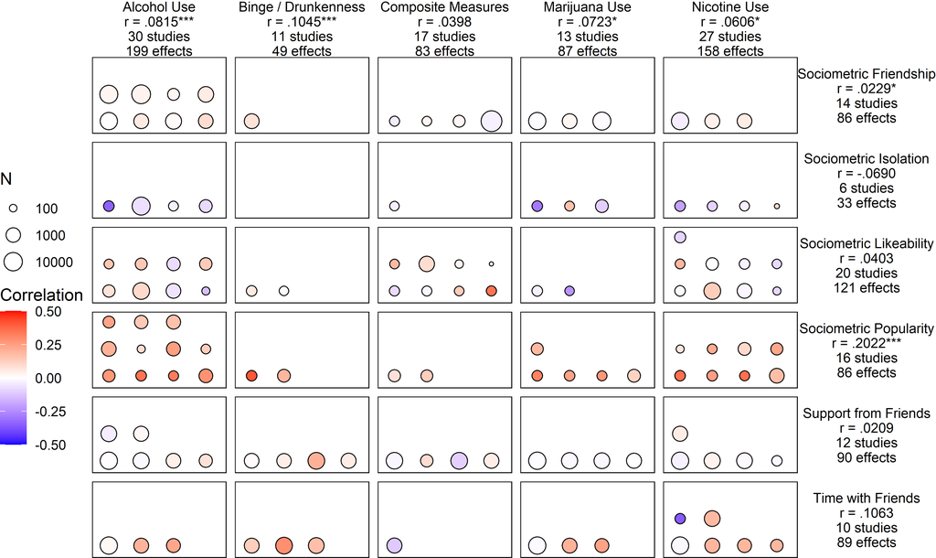

```r
ggplot(mat.data, aes(x = horiz, y = vert, fill = Correlation)) + geom_point(aes(size = N), pch = 21)+
  scale_size(trans = "log10") + xlim(c(-.01, 1.25)) + ylim(c(-.01, .85)) +
  scale_fill_gradient2(low = "blue", mid = "white", high = "red", midpoint = 0, limits = c(-.5, .5)) +
  theme_void() +
  theme(panel.border = element_rect(colour = "black", fill=NA, size=0.5),
        legend.position = "left") +
  facet_grid(PC.title ~ SU.title)
```

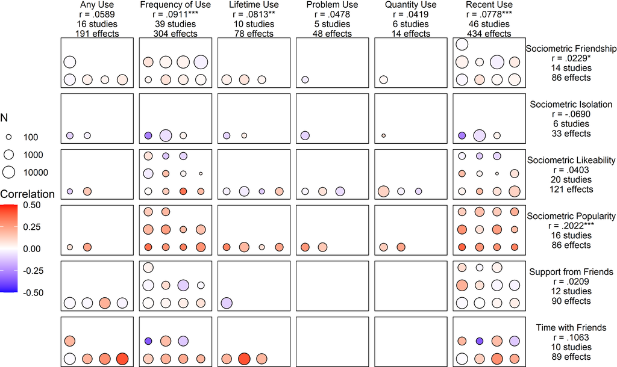

```r
ggplot(mat.data.2, aes(x = horiz, y = vert, fill = Correlation)) + geom_point(aes(size = N), pch = 21)+
  scale_size(trans = "log10") + xlim(c(-.01, 1.25)) + ylim(c(-.01, .85)) +
  scale_fill_gradient2(low = "blue", mid = "white", high = "red", midpoint = 0, limits = c(-.5, .5)) +
  theme_void() +
  theme(panel.border = element_rect(colour = "black", fill=NA, size=0.5),
        legend.position = "left") +
  facet_grid(PC.title ~ SU.title)
```

### Supplemental descriptives

In the Supplemental Materials, we provide a few more descriptive statistics about the different studies and effects we found. This code returns those plots and summary statistics. This corresponds to the analysis called *supplemental.R*. Note that, like the plotting code for Figure 2, we do not include the data management steps here – but in the original code we did.

```r
studylevel <- test[,c("Study", "pubyear", "Longitudinal", "Europe", "LatinAmerica", "AAO", "AfricaME")]
studylevel$pubyear <- studylevel$pubyear + 1996
yeardata <- unique(studylevel[,c("Study", "pubyear")])
yeardata <- as.data.frame(table(yeardata$pubyear))
names(yeardata) <- c("Year", "Frequency")


ggplot(data=yeardata, aes(x = Year, y = Frequency, group = 1)) +
  geom_line() +
  geom_point() +
  theme_minimal()
```

[figure not shown]

```r
table(test$Longitudinal)
```

```
##
##   0   1
## 791 407
```

```r
table(test$PC_outcome)
```

```
##
##    0    1
## 1082  116
```

```r
mean(test$Age, na.rm = TRUE)
```

```
## [1] 14.17409
```

```r
table(is.na(test$Age))
```

```
##
## FALSE  TRUE
##   671   527
```

```r
table(test$Gender) #87 effects were on male participants exclusively; 90 were on female participants exclusively
```

```
##
##     0  37.5    39  39.6  41.4  41.6    42    43  43.5    44  44.3    45  45.7
##    90     4     4     1     6     4    20    12     2   106    24    61     2
##    46  46.1  46.2  46.4  46.5  46.6  46.7  46.9    47 47.02 47.36  47.4  47.5
##    21     2     4    16     4     5    11     8    17     6    12     1     4
##  47.8  47.9    48  48.1 48.27  48.3 48.32  48.4  48.5  48.6  48.7  48.8  48.9
##    15    15    22     3     3     8     9     4    12     1     4    10    20
## 48.92    49  49.2  49.5  49.6  49.7  49.9 49.91    50  50.2 50.24  50.3 50.45
##     1    46     4     4    10    21     1     1    94    32     1     1     6
##  50.5  50.6  50.7    51  51.3  51.5  51.6  51.7    52  52.4  52.5  52.7  52.9
##    72     2     1     5     2     3    15     2    47    12     3     8     8
##    53  53.2    54  54.2  55.5  55.6    57  57.5  61.5  65.3   100
##    27     4     2     2     2    12     4     4    12     6    87
```

```r
genderdata <- subset(test, test$Gender != 0 & test$Gender != 100)
hist(genderdata$Gender, main = "Frequency of gender (coded as percent male) for each effect", xlab = "Percent male")
```

[figure not shown]

```r
hist(test$Age, xlab = "Age in Years", main = "Frequency of average age for each effect")
```

[figure not shown]